# Bridge Over Troubled Processes

Michael Betancourt

May 2022

Brownian motion is a fundamental stochastic process over trajectories that expands around a given initial state. A *Brownian bridge* restricts this Brownian motion to trajectories that also converge to a given terminal state. In this case study we will briefly review the implementation of both Brownian motion and Brownian bridges in Stan.

For a more rigorous discussion of Brownian motion and Brownian bridges see for example [1].

# 1 Preparation S

Before demonstrating how to implement Brownian motion and Brownian bridges in Stan we need to set up our local environment. Embracing vanity we first configure our graphics.

```r
library(colormap)

c_light <- c("#DCBCBC")
c_light_highlight <- c("#C79999")
c_mid <- c("#B97C7C")
c_mid_highlight <- c("#A25050")
c_dark <- c("#8F2727")
c_dark_highlight <- c("#7C0000")

nom_colors <- c("#DCBCBC", "#C79999", "#B97C7C", "#A25050", "#8F2727", "#7C0000")

c_light_teal <- c("#6B8E8E")
c_mid_teal <- c("#487575")
c_dark_teal <- c("#1D4F4F")

c_light_trans <- c("#DCBCBC80")
c_dark_trans <- c("#8F272780")
c_green_trans <- c("#00FF0080")

par(family="serif", las=1, bty="l", cex.axis=1, cex.lab=1, cex.main=1,
    xaxs="i", yaxs="i", mar = c(5, 5, 3, 1))
```

Then we ready Stan's `R` interface and my recommended diagnostics.

```r
library(rstan)
rstan_options(auto_write = TRUE)
options(mc.cores = parallel::detectCores())
parallel:::setDefaultClusterOptions(setup_strategy = "sequential")

util <- new.env()
source('stan_utility.R', local=util)
```

Finally let's define some functions for visualizing trajectory behavior.

```r
plot_realizations <- function(t, x, name, ylim=c(-3, 7)) {
  I <- length(x[,1])

  plot_idx <- seq(1, I, 80)
  J <- length(plot_idx)
  line_colors <- colormap(colormap=nom_colors, nshades=J)

  plot(1, type="n", xlab="Time", ylab="State", main=name,
       xlim=c(t[1], t[length(t)]), ylim=ylim)
  for (j in 1:J)
    lines(t, x[plot_idx[j],], col=line_colors[j], lwd=2)
}

plot_marginal_quantiles <- function(t, x, name, ylim=c(-3, 7)) {
  probs = c(0.1, 0.2, 0.3, 0.4, 0.5, 0.6, 0.7, 0.8, 0.9)
  cred <- sapply(1:length(t), function(n) quantile(x[,n], probs=probs))

  plot(1, type="n", main=name,
       xlab="Time", ylab="State", xlim=c(t[1], t[length(t)]), ylim=ylim)
  polygon(c(t, rev(t)), c(cred[1,], rev(cred[9,])),
          col = c_light, border = NA)
  polygon(c(t, rev(t)), c(cred[2,], rev(cred[8,])),
          col = c_light_highlight, border = NA)
  polygon(c(t, rev(t)), c(cred[3,], rev(cred[7,])),
          col = c_mid, border = NA)
  polygon(c(t, rev(t)), c(cred[4,], rev(cred[6,])),
          col = c_mid_highlight, border = NA)
  lines(t, cred[5,], col=c_dark, lwd=2)
}
```

# 2 Brownian Motion

Brownian motion features a few useful interpretations. On one hand we can interpret it as a probability distribution over continuous but non-differentiable trajectories across some time interval $t \in [0, T]$ bound to a fixed initial state $x(t = 0) = x_{0}$. At the same time we can interpret it as an evolving probability distribution specified by a probability density function that expands around the initial state,
$$\pi(x_{n} \mid x_{0}, t_{n})
=
\text{normal} \left( x_{n} \mid x_{0}, \sqrt{t_{n}} \right).$$

From either perspective if we project Brownian motion to only a finite set of states
$$\{ x_{1}, \ldots, x_{n}, \ldots, x_{N} \}$$
at the times
$$0 < t_{1} < \ldots < t_{n} < \ldots < t_{N}$$
then it reduces to a finite-dimensional probability distribution specified by the probability density function
$$\pi(x_{1}, \ldots, x_{N} \mid x_{0}, t_{1}, \ldots, t_{N})
=
\prod_{n = 1}^{N} \pi(x_{n} \mid x_{n - 1}, t_{n}, t_{n - 1})$$
where
$$\pi(x_{n} \mid x_{n - 1}, t_{n}, t_{n - 1})
=
\text{normal} \left( x_{n} \mid x_{n - 1}, \sqrt{t_{n} - t_{n - 1}} \right).$$
The longer the gap between sequential states the less coupled they will be.

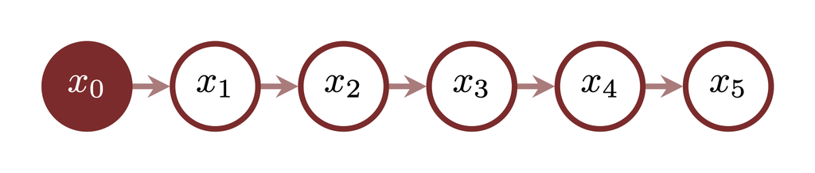

Given $x_{0}$ and the times $t_{1}, \ldots, t_{N}$ this Brownian motion is straightforward to implement in Stan. Note that I use $1$-indexing in the Stan program for convenience which ever-so-slightly deviates from the $0$-indexing used in the mathematical notation and figures.

```r
writeLines(readLines("stan_programs/brownian_motion_prior_cp.stan"))
```

```
data {
  int<lower=1> N;
  real ts[N];

  real x_left;
}

parameters {
  real xs_forward[N - 1];
}

transformed parameters {
  real xs[N] = append_array(rep_array(x_left, 1), xs_forward);
}

model {
  for (n in 2:N) {
    xs[n] ~ normal(xs[n - 1], sqrt(ts[n] - ts[n - 1]) );
  }
}
```

Before attempting to fit this model we need to define the states. Here we will use a relatively fine discretization of the time interval $[0, 1]$.

```r
t_min <- 0
t_max <- 1
N <- 500

ts <- seq(t_min, t_max, (t_max - t_min) / (N - 1))
```

The variable `x_left` will capture the initial state at $t = 0$.

```r
x_left <- +1

data <- list("N" = N, "ts" = ts, "x_left" = x_left)
```

With the states ready we can attempt to fit the Brownian motion model in Stan. The parser diagnostic here is a false positive due to packing both the fixed initial state and the other, varying states into a single array.

```r
fit <- stan(file='stan_programs/brownian_motion_prior_cp.stan',
            data=data, seed=494838, refresh=2000)
```

```
DIAGNOSTIC(S) FROM PARSER:
Info:
Left-hand side of sampling statement (~) may contain a non-linear transform of a parameter or local variable.
If it does, you need to include a target += statement with the log absolute determinant of the Jacobian of the transform.
Left-hand-side of sampling statement:
    xs[n] ~ normal(...)
```

Unfortunately Stan's dynamic Hamiltonian Monte Carlo sampler is repeatedly hitting the maximum treedepth wall. The `n_eff` and `Rhat` warnings here are false positives from the fixed initial state.

```r
util$check_all_diagnostics(fit)
```

```
[1] "n_eff for parameter xs[1] is NaN!"
[1] "  n_eff / iter below 0.001 indicates that the effective sample size has likely been overestimated"
[1] "Rhat for parameter xs[1] is NaN!"
[1] "  Rhat above 1.1 indicates that the chains very likely have not mixed"
[1] "0 of 4000 iterations ended with a divergence (0%)"
[1] "2488 of 4000 iterations saturated the maximum tree depth of 10 (62.2%)"
[1] "  Run again with max_treedepth set to a larger value to avoid saturation"
[1] "E-FMI indicated no pathological behavior"
```

The problem here is that this centered parameterization of the Brownian motion model induces strong correlations between all of the neighboring states. These strong correlations require a small step size and very long numerical trajectories for Hamiltonian Monte Carlo to be able to accurately explore.

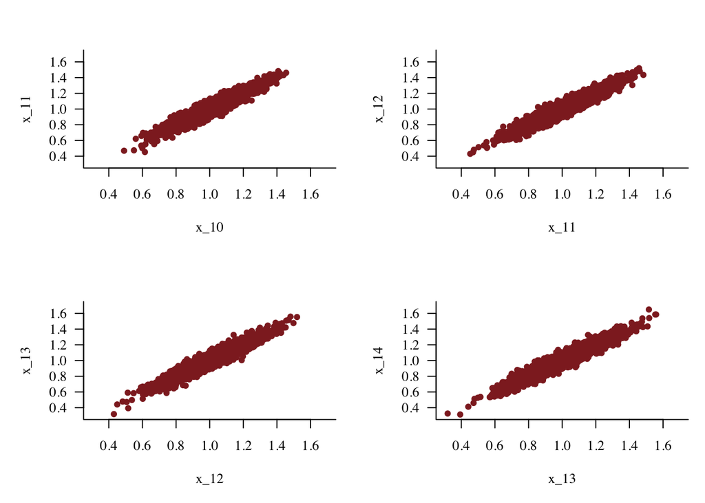

```r
samples <- extract(fit)

par(mfrow=c(2, 2))

plot(samples$xs[,10], samples$xs[,11], col=c_dark, pch=16,
     xlab="x_10", xlim=c(0.25, 1.75), ylab="x_11", ylim=c(0.25, 1.75))

plot(samples$xs[,11], samples$xs[,12], col=c_dark, pch=16,
     xlab="x_11", xlim=c(0.25, 1.75), ylab="x_12", ylim=c(0.25, 1.75))

plot(samples$xs[,12], samples$xs[,13], col=c_dark, pch=16,
     xlab="x_12", xlim=c(0.25, 1.75), ylab="x_13", ylim=c(0.25, 1.75))

plot(samples$xs[,13], samples$xs[,14], col=c_dark, pch=16,
     xlab="x_13", xlim=c(0.25, 1.75), ylab="x_14", ylim=c(0.25, 1.75))
```

We can avoid these correlations with a non-centered parameterization of the model.

```r
writeLines(readLines("stan_programs/brownian_motion_prior_ncp.stan"))
```

```
data {
  int<lower=1> N;
  real ts[N];

  real x_left;
}

parameters {
  real xs_forward_ncp[N - 1];
}

transformed parameters {
  real xs[N];

  xs[1] = x_left;

  for (n in 2:N) {
    xs[n]
      = xs[n - 1] + sqrt(ts[n] - ts[n - 1]) * xs_forward_ncp[n - 1];
  }
}

model {
  xs_forward_ncp ~ normal(0, 1);
}
```

```r
fit <- stan(file='stan_programs/brownian_motion_prior_ncp.stan',
            data=data, seed=494838, refresh=2000)

util$check_all_diagnostics(fit)
```

```
[1] "n_eff for parameter xs[1] is NaN!"
[1] "  n_eff / iter below 0.001 indicates that the effective sample size has likely been overestimated"
[1] "Rhat for parameter xs[1] is NaN!"
[1] "  Rhat above 1.1 indicates that the chains very likely have not mixed"
[1] "0 of 4000 iterations ended with a divergence (0%)"
[1] "0 of 4000 iterations saturated the maximum tree depth of 10 (0%)"
[1] "E-FMI indicated no pathological behavior"
```

The nicer geometry afforded by the non-centered parameterization is no problem for Stan to quantify both quickly and accurately. Using this fit we can immediately visualize the Brownian motion.

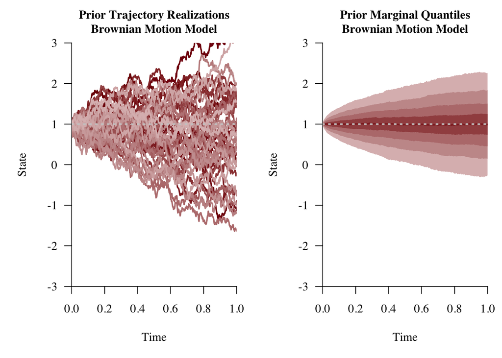

```r
samples <- extract(fit)

par(mfrow=c(1, 2))

plot_realizations(ts, samples$xs,
                  "Prior Trajectory Realizations\nBrownian Motion Model",
                  c(-3, 3))
abline(h=data$x_left, col="gray80", lwd=2, lty=3)

plot_marginal_quantiles(ts, samples$xs,
                        "Prior Marginal Quantiles\nBrownian Motion Model",
                        c(-3, 3))
abline(h=data$x_left, col="gray80", lwd=2, lty=3)
```

If we have observations of any states then this Brownian motion model becomes a prior model that we can update into a posterior distribution. Consider, for example, a normal observational model with a known variability,
$$\pi(x_{\text{obs}, m} \mid x_{\text{obs_idx}(m)}, \sigma)
=
\text{normal}(x_{\text{obs}, m} \mid x_{\text{obs_idx}(m)}, \sigma),$$
which we assume gives rise to the following observation.

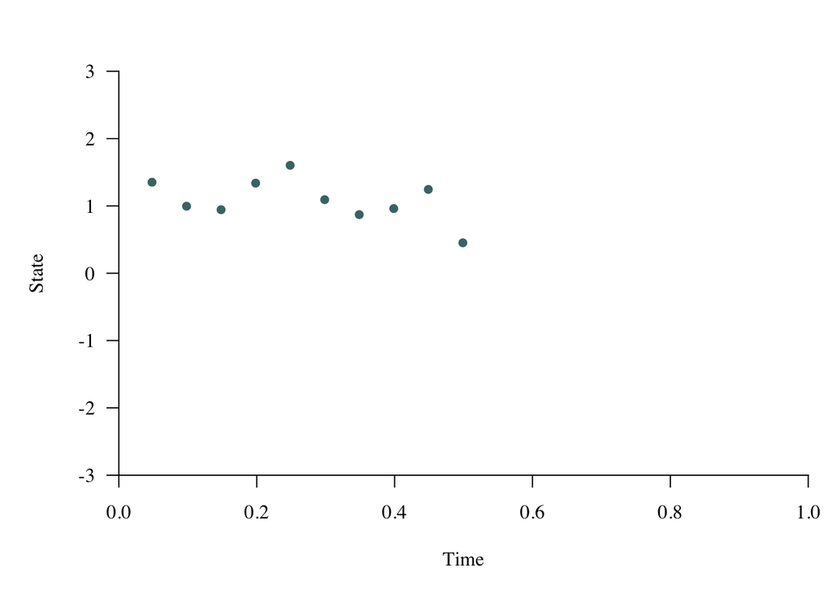

```r
data <- read_rdump("data/obs.data.R")

par(mfrow=c(1, 1))

plot(data$ts[data$obs_idx], data$x_obs, pch=16, col=c_mid_teal,
     xlim=c(0, 1), xlab="Time", ylim=c(-3, 3), ylab="State")
```

Adding this observational model to our Stan program allows us to quantify the Brownian motion trajectories that are compatible with this observation.

```r
writeLines(readLines("stan_programs/brownian_motion_post_ncp.stan"))
```

```
data {
  int<lower=1> N;
  real ts[N];

  real x_left;

  int<lower=1> N_obs;
  int<lower=1, upper=N + 1> obs_idx[N_obs];
  real x_obs[N_obs];
  real<lower=0> sigma;
}

parameters {
  real xs_forward_ncp[N - 1];
}

transformed parameters {
  real xs[N];

  xs[1] = x_left;

  for (n in 2:N) {
    xs[n]
      = xs[n - 1] + sqrt(ts[n] - ts[n - 1]) * xs_forward_ncp[n - 1];
  }
}

model {
  xs_forward_ncp ~ normal(0, 1);
  x_obs ~ normal(xs[obs_idx], sigma);
}
```

```r
fit <- stan(file='stan_programs/brownian_motion_post_ncp.stan',
            data=data, seed=494838, refresh=2000)

util$check_all_diagnostics(fit)
```

```
[1] "n_eff for parameter xs[1] is NaN!"
[1] "  n_eff / iter below 0.001 indicates that the effective sample size has likely been overestimated"
[1] "Rhat for parameter xs[1] is NaN!"
[1] "  Rhat above 1.1 indicates that the chains very likely have not mixed"
[1] "0 of 4000 iterations ended with a divergence (0%)"
[1] "0 of 4000 iterations saturated the maximum tree depth of 10 (0%)"
[1] "E-FMI indicated no pathological behavior"
```

With this non-centered parameterization we see no indications of fitting problems that would instill doubt in the accuracy of our posterior quantification.

Indeed the resulting posterior stochastic process threads through the observed data.

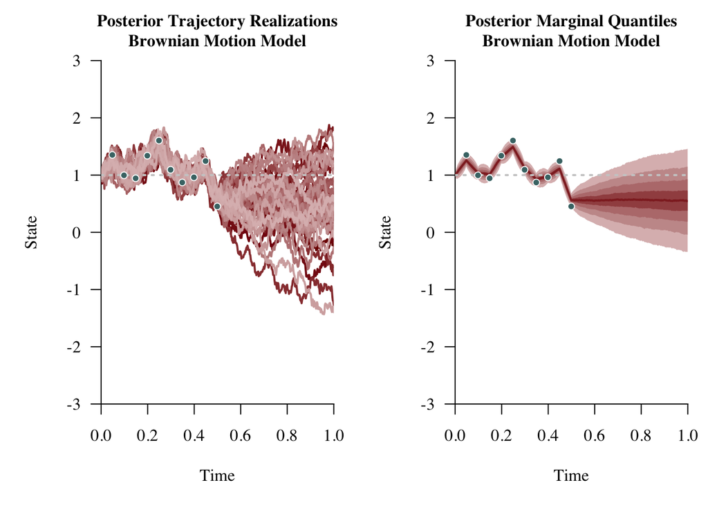

```r
samples <- extract(fit)

par(mfrow=c(1, 2))

plot_realizations(ts, samples$xs,
                  "Posterior Trajectory Realizations\nBrownian Motion Model",
                  c(-3, 3))

abline(h=data$x_left, col="gray80", lwd=2, lty=3)

points(data$ts[data$obs_idx], data$x_obs, pch=16, cex=1.00, col="white")
points(data$ts[data$obs_idx], data$x_obs, pch=16, cex=0.75, col=c_mid_teal)

plot_marginal_quantiles(ts, samples$xs,
                        "Posterior Marginal Quantiles\nBrownian Motion Model",
                        c(-3, 3))

abline(h=data$x_left, col="gray80", lwd=2, lty=3)

points(data$ts[data$obs_idx], data$x_obs, pch=16, cex=1.00, col="white")
points(data$ts[data$obs_idx], data$x_obs, pch=16, cex=0.75, col=c_mid_teal)
```

# 3 Brownian Bridges

One limitation of the Brownian motion model is that it can account for only an initial condition. In some applications, however, we privileged with *boundary conditions* that fix both an initial state at $t = 0$ *and* a terminal state at $t = T$. Without being able to accommodate this terminal condition the Brownian motion model can provide poor inferences as we extrapolate to later times.

For example let's assume that we know that our system converges to a terminal state `x_right = -1` at $t = T$. Inferences using the Brownian motion prior model poorly capture the true behavior of the system as we move further away from $t = 0$ and closer to $t = T$.

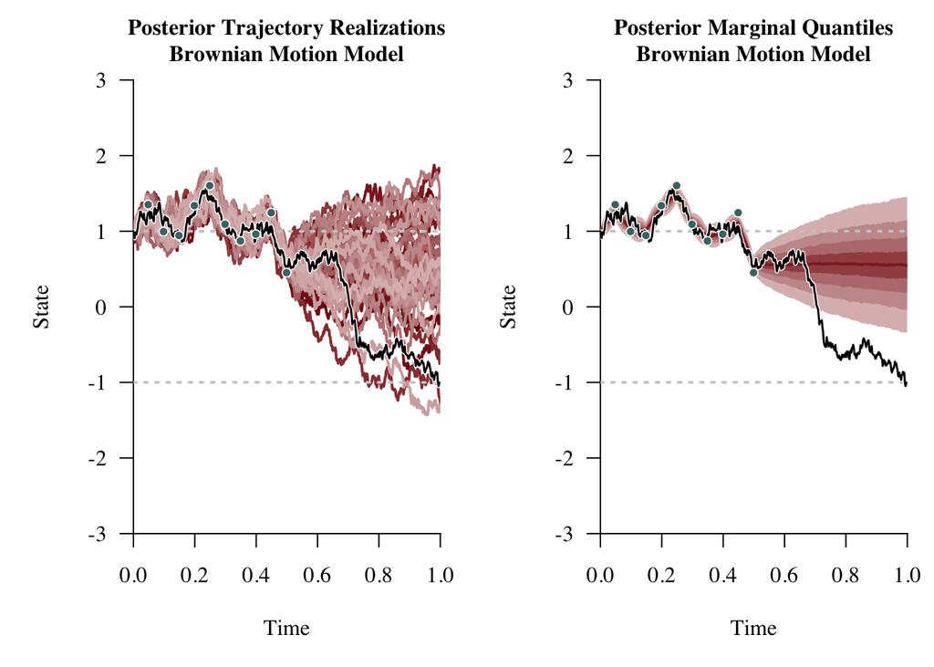

```r
truth <- read_rdump("data/truth.data.R")

par(mfrow=c(1, 2))

plot_realizations(ts, samples$xs,
                  "Posterior Trajectory Realizations\nBrownian Motion Model",
                  c(-3, 3))

abline(h=data$x_left, col="gray80", lwd=2, lty=3)
abline(h=data$x_right, col="gray80", lwd=2, lty=3)

lines(data$ts, truth$xs, lwd=3, col="white")
lines(data$ts, truth$xs, lwd=1.5, col="black")

points(data$ts[data$obs_idx], data$x_obs, pch=16, cex=1.00, col="white")
points(data$ts[data$obs_idx], data$x_obs, pch=16, cex=0.75, col=c_mid_teal)

plot_marginal_quantiles(ts, samples$xs,
                        "Posterior Marginal Quantiles\nBrownian Motion Model",
                        c(-3, 3))

abline(h=data$x_left, col="gray80", lwd=2, lty=3)
abline(h=data$x_right, col="gray80", lwd=2, lty=3)

lines(data$ts, truth$xs, lwd=3, col="white")
lines(data$ts, truth$xs, lwd=1.5, col="black")

points(data$ts[data$obs_idx], data$x_obs, pch=16, cex=1.00, col="white")
points(data$ts[data$obs_idx], data$x_obs, pch=16, cex=0.75, col=c_mid_teal)
```

A Brownian bridge restricts Brownian motion to respect a complete set of boundary conditions. Mathematically the behavior of each state in a Brownian bridge is defined conditional not on a single previous state but rather on two *bounding* states,
$$\pi(x_{n} \mid x_{l}, x_{m}, t_{l}, t_{n}, t_{m})
=
\text{normal} \left( x_{n} \mid
x_{l} + \frac{t_{n} - t_{l}}{t_{m} - t_{l}} \, (x_{m} - x_{l}),
\sqrt{ \frac{ (t_{m} - t_{n}) \, (t_{n} - t_{l}) }{ t_{m} - t_{l} } } \right).$$
where
$$t_{l} < t_{n} < t_{m}.$$

A consistent model for multiple interior states is then defined through a conditional decomposition of the form
$$\pi(x_{1}, \ldots, x_{N} \mid
x_{0}, x_{N + 1}, t_{0}, t_{1}, \ldots, t_{N}, t_{N + 1})
=
\prod_{n = 1}^{N} \pi(x_{\text{center}(n)} \mid
x_{\text{left}(n)}, x_{\text{right}(n)},
t_{\text{left}(n)}, t_{\text{center}(n)}, t_{\text{right}(n)})$$
where
$$t_{\text{left}(n)} < t_{\text{center}(n)} < t_{\text{right}(n)}$$
and
$$\text{center}^{-1} \circ \text{left}(n) < n
\\
\text{center}^{-1} \circ \text{right}(n) < n.$$
In other words we need to surround each interior state with two states that have already been considered in the decomposition.

Given a consistent decomposition the Brownian bridge model is straightforward to implement in Stan. With wisdom aforethough we jump directly to a non-centered parameterization.

```r
writeLines(readLines("stan_programs/brownian_bridge_prior_ncp.stan"))
```

```
functions {
  real bridge_lpdf(real x, real t, real t_left, real x_left, real t_right, real x_right) {
    real mu = x_left + (t - t_left) / (t_right - t_left) * (x_right - x_left);
    real sigma2 = (t_right - t) * (t - t_left) / (t_right - t_left);
    return normal_lpdf(x | mu, sqrt(sigma2));
  }

  real bridge_rng(real t, real t_left, real x_left, real t_right, real x_right) {
    real mu = x_left + (t - t_left) / (t_right - t_left) * (x_right - x_left);
    real sigma2 = (t_right - t) * (t - t_left) / (t_right - t_left);
    return normal_rng(mu, sqrt(sigma2));
  }
}

data {
  int<lower=1> N;
  real ts[N];

  real x_left;
  real x_right;

  int left_idxs[N - 2];
  int center_idxs[N - 2];
  int right_idxs[N - 2];
}

parameters {
  real interior_x_tildes[N - 2];
}

transformed parameters {
  real xs[N];

  xs[1] = x_left;
  xs[N] = x_right;

  for (n in 1:(N - 2)) {
    real t = ts[center_idxs[n]];
    real t_l = ts[left_idxs[n]];
    real x_l = xs[left_idxs[n]];
    real t_r = ts[right_idxs[n]];
    real x_r =  xs[right_idxs[n]];

    real mu = x_l + (t - t_l) / (t_r - t_l) * (x_r - x_l);
    real sigma2 = (t_r - t) * (t - t_l) / (t_r - t_l);

    xs[center_idxs[n]] = mu + sqrt(sigma2) * interior_x_tildes[n];
  }
}

model {
  interior_x_tildes ~ normal(0, 1);
}
```

```r
writeLines(readLines("stan_programs/brownian_bridge_post_ncp.stan"))
```

```
functions {
  real bridge_lpdf(real x, real t, real t_left, real x_left, real t_right, real x_right) {
    real mu = x_left + (t - t_left) / (t_right - t_left) * (x_right - x_left);
    real sigma2 = (t_right - t) * (t - t_left) / (t_right - t_left);
    return normal_lpdf(x | mu, sqrt(sigma2));
  }

  real bridge_rng(real t, real t_left, real x_left, real t_right, real x_right) {
    real mu = x_left + (t - t_left) / (t_right - t_left) * (x_right - x_left);
    real sigma2 = (t_right - t) * (t - t_left) / (t_right - t_left);
    return normal_rng(mu, sqrt(sigma2));
  }
}

data {
  int<lower=1> N;
  real ts[N];

  real x_left;
  real x_right;

  int left_idxs[N - 2];
  int center_idxs[N - 2];
  int right_idxs[N - 2];

  int<lower=1> N_obs;
  int obs_idx[N_obs];
  real x_obs[N_obs];
  real<lower=0> sigma;
}

parameters {
  real xs_interior_ncp[N - 2];
}

transformed parameters {
  real xs[N];

  xs[1] = x_left;
  xs[N] = x_right;

  for (n in 1:(N - 2)) {
    real t = ts[center_idxs[n]];
    real t_l = ts[left_idxs[n]];
    real x_l = xs[left_idxs[n]];
    real t_r = ts[right_idxs[n]];
    real x_r =  xs[right_idxs[n]];

    real mu = x_l + (t - t_l) / (t_r - t_l) * (x_r - x_l);
    real sigma2 = (t_r - t) * (t - t_l) / (t_r - t_l);

    xs[center_idxs[n]] = mu + sqrt(sigma2) * xs_interior_ncp[n];
  }
}

model {
  xs_interior_ncp ~ normal(0, 1);
  x_obs ~ normal(xs[obs_idx], sigma);
}
```

Fortunately there are many decompositions that we can employ in practice; here we will explore just a few.

## 3.1 Sequential Decomposition

One possibility is to run through each of the interior states in order, using the previous state and the terminal state as boundaries. I will refer to this as a *sequential decomposition*.

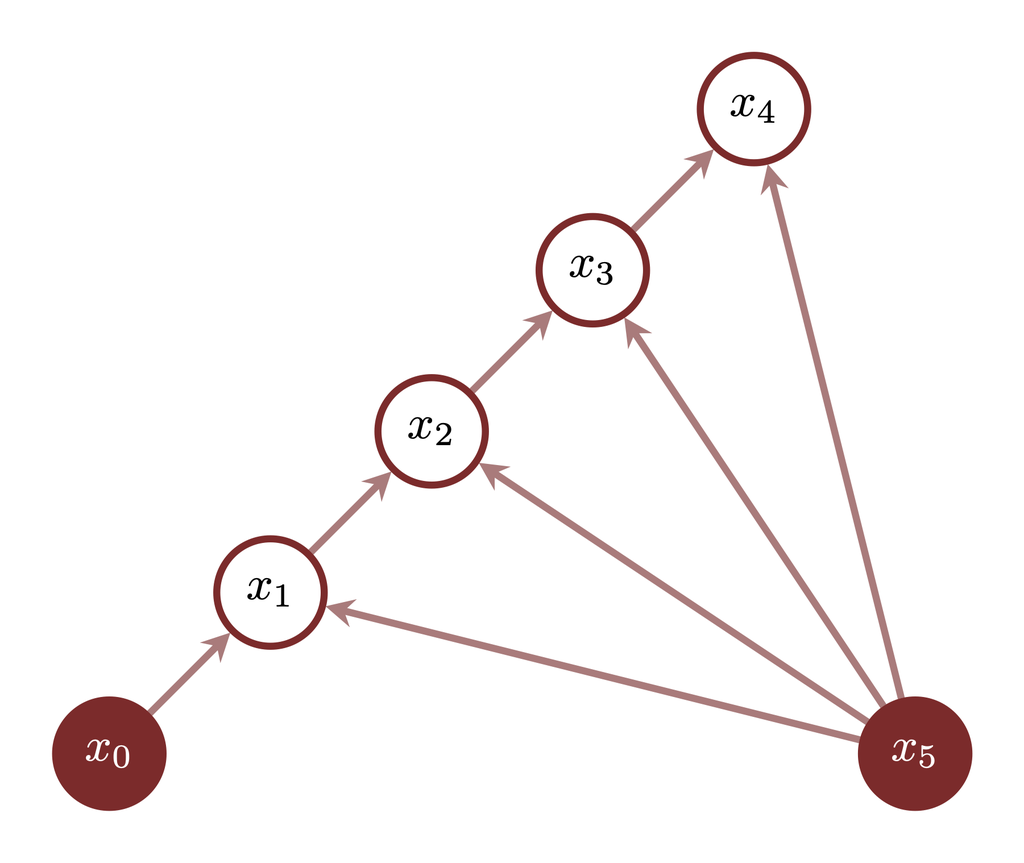

This decomposition is particularly straightforward to implement programatically.

```r
data$left_idxs <- 1:(data$N - 2)
data$center_idxs <- 2:(data$N - 1)
data$right_idxs <- rep(data$N, data$N - 2)
```

Given the decomposition we can quantify the consequences of the Brownian bridge prior model with Stan.

```r
fit <- stan(file='stan_programs/brownian_bridge_prior_ncp.stan', data=data,
            seed=494838, refresh=2000)
```

In this case we have multiple false positives from the two fixed boundary states that we've included in the `xs` array.

```r
util$check_all_diagnostics(fit)
```

```
[1] "n_eff for parameter xs[1] is NaN!"
[1] "n_eff for parameter xs[500] is NaN!"
[1] "  n_eff / iter below 0.001 indicates that the effective sample size has likely been overestimated"
[1] "Rhat for parameter xs[1] is NaN!"
[1] "Rhat for parameter xs[500] is NaN!"
[1] "  Rhat above 1.1 indicates that the chains very likely have not mixed"
[1] "0 of 4000 iterations ended with a divergence (0%)"
[1] "0 of 4000 iterations saturated the maximum tree depth of 10 (0%)"
[1] "E-FMI indicated no pathological behavior"
```

Like the Brownian motion model all of the realized trajectories are bound to the initial state, but unlike the Brownian motion all of the realized trajectories are also bound to the terminal state.

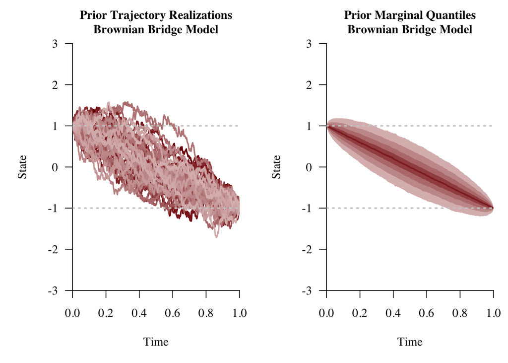

```r
samples <- extract(fit)

par(mfrow=c(1, 2))

plot_realizations(ts, samples$xs,
                  "Prior Trajectory Realizations\nBrownian Bridge Model",
                  c(-3, 3))

abline(h=data$x_left, col="gray80", lwd=2, lty=3)
abline(h=data$x_right, col="gray80", lwd=2, lty=3)

plot_marginal_quantiles(ts, samples$xs,
                        "Prior Marginal Quantiles\nBrownian Bridge Model",
                        c(-3, 3))

abline(h=data$x_left, col="gray80", lwd=2, lty=3)
abline(h=data$x_right, col="gray80", lwd=2, lty=3)
```

Adding the observational model allows us to quantify the trajectories compatible with not only the initial state and terminal state but also the observed data.

```r
fit <- stan(file='stan_programs/brownian_bridge_post_ncp.stan', data=data,
            seed=494838, refresh=2000)
```

```r
util$check_all_diagnostics(fit)
```

```
[1] "n_eff for parameter xs[1] is NaN!"
[1] "n_eff for parameter xs[500] is NaN!"
[1] "  n_eff / iter below 0.001 indicates that the effective sample size has likely been overestimated"
[1] "Rhat for parameter xs[1] is NaN!"
[1] "Rhat for parameter xs[500] is NaN!"
[1] "  Rhat above 1.1 indicates that the chains very likely have not mixed"
[1] "0 of 4000 iterations ended with a divergence (0%)"
[1] "0 of 4000 iterations saturated the maximum tree depth of 10 (0%)"
[1] "E-FMI indicated no pathological behavior"
```

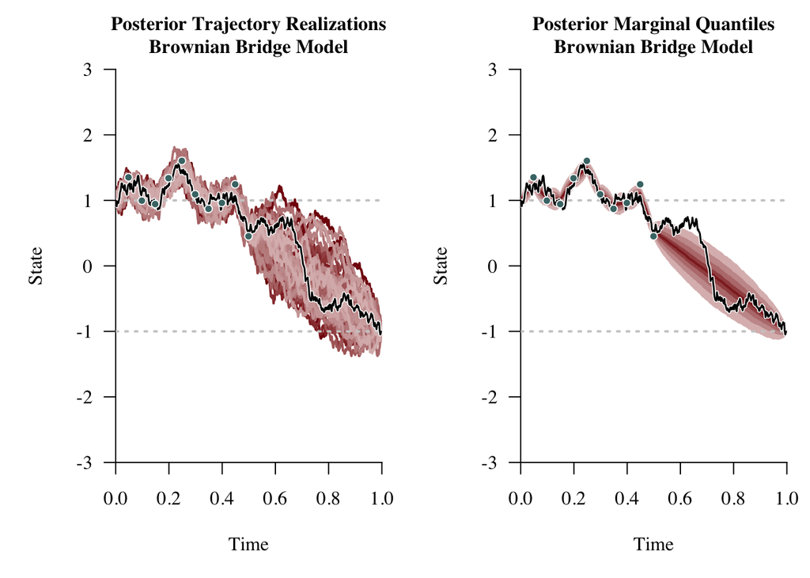

```r
samples <- extract(fit)

par(mfrow=c(1, 2))

plot_realizations(ts, samples$xs,
                  "Posterior Trajectory Realizations\nBrownian Bridge Model",
                  c(-3, 3))

abline(h=data$x_left, col="gray80", lwd=2, lty=3)
abline(h=data$x_right, col="gray80", lwd=2, lty=3)

lines(data$ts, truth$xs, lwd=3, col="white")
lines(data$ts, truth$xs, lwd=1.5, col="black")

points(data$ts[data$obs_idx], data$x_obs, pch=16, cex=1.00, col="white")
points(data$ts[data$obs_idx], data$x_obs, pch=16, cex=0.75, col=c_mid_teal)

plot_marginal_quantiles(ts, samples$xs,
                        "Posterior Marginal Quantiles\nBrownian Bridge Model",
                        c(-3, 3))

abline(h=data$x_left, col="gray80", lwd=2, lty=3)
abline(h=data$x_right, col="gray80", lwd=2, lty=3)

lines(data$ts, truth$xs, lwd=3, col="white")
lines(data$ts, truth$xs, lwd=1.5, col="black")

points(data$ts[data$obs_idx], data$x_obs, pch=16, cex=1.00, col="white")
points(data$ts[data$obs_idx], data$x_obs, pch=16, cex=0.75, col=c_mid_teal)
```

## 3.2 Recursive Decomposition

Instead of working through the interior states sequentially we can also work through them with recursive bisections. We start by selecting an interior state $x_{s}$ temporally bounded by the initial and terminal states,
$$t_{0} < t_{s} < t_{N - 1}.$$
This choice bisects the remaining states into two segments: one with states bounded by $t_{0}$ and $t_{s}$ and the other with states bounded by $t_{s}$ and $t_{N - 1}$. At this point we can repeat the procedure on each group until we have exhausted all of the interior states.

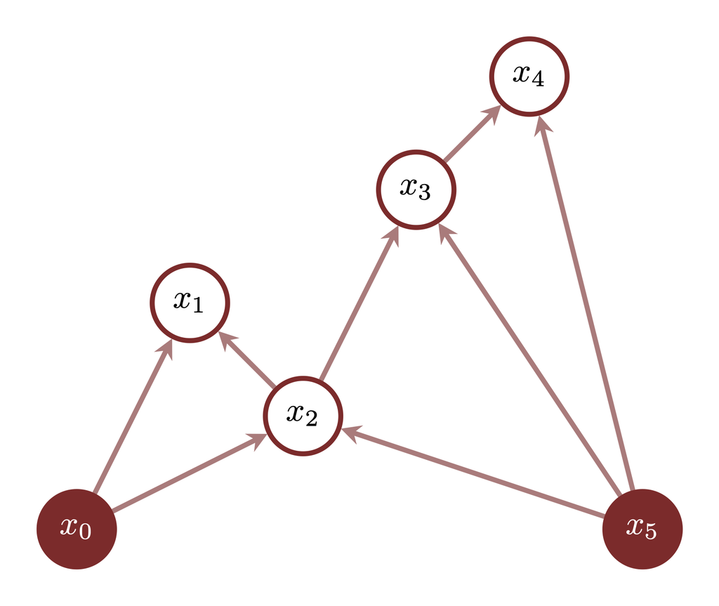

Programming this decomposition is a bit more difficult, but still manageable with some careful recursion.

```r
construct_boundaries <- function(left_idx, right_idx) {

  delta <- right_idx - left_idx
  if (delta > 1) {
    center_idx <- left_idx + delta %/% 2

    idxs <- list(c(left_idx, center_idx, right_idx))
    idxs <- append(idxs, construct_boundaries(left_idx, center_idx))
    idxs <- append(idxs, construct_boundaries(center_idx, right_idx))
  }
}
```

For example we recover the decomposition in the figure using `0`-indexing,

```r
idxs <- construct_boundaries(0, 5)
for(idx in idxs) {
  cat(paste0(idx, ","))
  cat("\n")
}
```

```
0, 2, 5,
0, 1, 2,
2, 3, 5,
3, 4, 5,
```

Our Stan implementation, however, requires `1`-indexing.

```r
idxs <- construct_boundaries(1, data$N)

data$left_idxs <- sapply(idxs, function(idx) idx[1])
data$center_idxs <- sapply(idxs, function(idx) idx[2])
data$right_idxs <- sapply(idxs, function(idx) idx[3])
```

```r
fit <- stan(file='stan_programs/brownian_bridge_prior_ncp.stan', data=data,
            seed=494838, refresh=2000)
```

```r
util$check_all_diagnostics(fit)
```

```
[1] "n_eff for parameter xs[1] is NaN!"
[1] "n_eff for parameter xs[500] is NaN!"
[1] "  n_eff / iter below 0.001 indicates that the effective sample size has likely been overestimated"
[1] "Rhat for parameter xs[1] is NaN!"
[1] "Rhat for parameter xs[500] is NaN!"
[1] "  Rhat above 1.1 indicates that the chains very likely have not mixed"
[1] "0 of 4000 iterations ended with a divergence (0%)"
[1] "0 of 4000 iterations saturated the maximum tree depth of 10 (0%)"
[1] "E-FMI indicated no pathological behavior"
```

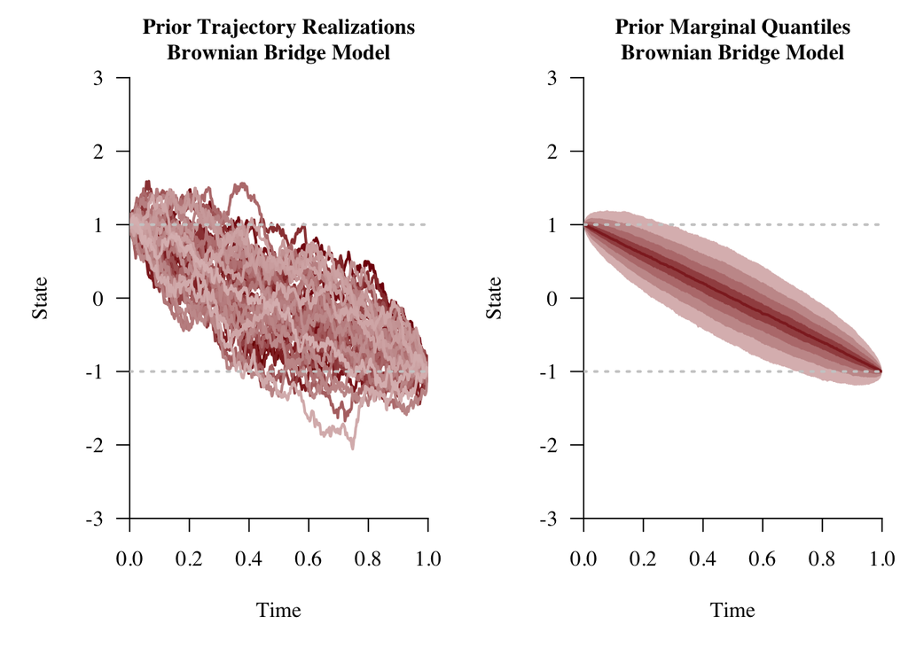

```r
samples <- extract(fit)

par(mfrow=c(1, 2))

plot_realizations(ts, samples$xs,
                  "Prior Trajectory Realizations\nBrownian Bridge Model",
                  c(-3, 3))
abline(h=data$x_left, col="gray80", lwd=2, lty=3)
abline(h=data$x_right, col="gray80", lwd=2, lty=3)

plot_marginal_quantiles(ts, samples$xs,
                        "Prior Marginal Quantiles\nBrownian Bridge Model",
                        c(-3, 3))
abline(h=data$x_left, col="gray80", lwd=2, lty=3)
abline(h=data$x_right, col="gray80", lwd=2, lty=3)
```

Likewise the posterior inferences are equivalent.

```r
fit <- stan(file='stan_programs/brownian_bridge_post_ncp.stan', data=data,
            seed=494838, refresh=2000)
```

```r
util$check_all_diagnostics(fit)
```

```
[1] "n_eff for parameter xs[1] is NaN!"
[1] "n_eff for parameter xs[500] is NaN!"
[1] "  n_eff / iter below 0.001 indicates that the effective sample size has likely been overestimated"
[1] "Rhat for parameter xs[1] is NaN!"
[1] "Rhat for parameter xs[500] is NaN!"
[1] "  Rhat above 1.1 indicates that the chains very likely have not mixed"
[1] "0 of 4000 iterations ended with a divergence (0%)"
[1] "0 of 4000 iterations saturated the maximum tree depth of 10 (0%)"
[1] "E-FMI indicated no pathological behavior"
```

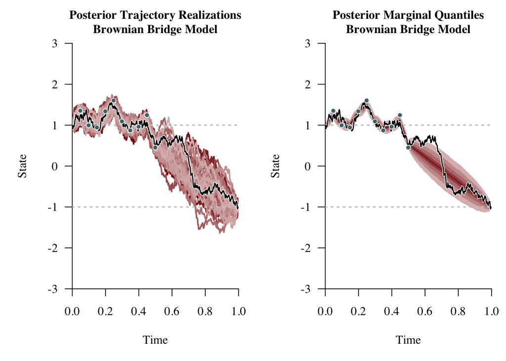

```r
samples <- extract(fit)

par(mfrow=c(1, 2))

plot_realizations(ts, samples$xs,
                  "Posterior Trajectory Realizations\nBrownian Bridge Model",
                  c(-3, 3))

abline(h=data$x_left, col="gray80", lwd=2, lty=3)
abline(h=data$x_right, col="gray80", lwd=2, lty=3)

lines(data$ts, truth$xs, lwd=3, col="white")
lines(data$ts, truth$xs, lwd=1.5, col="black")

points(data$ts[data$obs_idx], data$x_obs, pch=16, cex=1.00, col="white")
points(data$ts[data$obs_idx], data$x_obs, pch=16, cex=0.75, col=c_mid_teal)

plot_marginal_quantiles(ts, samples$xs,
                        "Posterior Marginal Quantiles\nBrownian Bridge Model",
                        c(-3, 3))

abline(h=data$x_left, col="gray80", lwd=2, lty=3)
abline(h=data$x_right, col="gray80", lwd=2, lty=3)

lines(data$ts, truth$xs, lwd=3, col="white")
lines(data$ts, truth$xs, lwd=1.5, col="black")

points(data$ts[data$obs_idx], data$x_obs, pch=16, cex=1.00, col="white")
points(data$ts[data$obs_idx], data$x_obs, pch=16, cex=0.75, col=c_mid_teal)
```